# Rotation Study Analysis: Overview and Part 1 - Plant Performance

Created April 2, 2020

PME

03 September, 2020, 21:32

# Overview

1. Rotations. 4 replicates of each
2. Corn-Pea-Winter Wheat-Soybean (CSWS)
3. Corn-Soybean-Spring Wheat-Sunflower (CSSwSf)
4. Corn-Soybean-Spring Wheat-Pea (CSSwP)
5. Corn-Oats-Winter Wheat-Soybean (COWP)
6. Corn-Soybean (CS)
7. Crops Sampled:
8. Corn
9. Soybean
10. Timepoints:
11. V2. Plant biomass, tissue, soil temp/moisture, microbial community
12. R1/Flowering. Same as V2, plus soil carbon/nitrogen
13. Maturity. Yield.

## Hypotheses

We have hypothesized, based on observations on this long-term study as well as other plots, that both crops will yield better in long rotations. We hypothesize that nutrient uptake will not drive this observation. Instead, based on greenhouse results (Benitez-Ponce et al, 2018), long rotations will induce beneficial microbial communities. Finally, we hypothesize that a critical aspect of rotation is the inclusion of sunflower, based again on results from Benitez-Ponce et al (2018). Alternativly, the previous crop and rotation length may be important.

In addition to testing these hypotheses, we hope to propose microbial community characteristics (taxa, etc) that are both responsive to rotation and predictive of plant health. These characteristics will form the basis for further study to validate.

## Workflow

The goals and workflow are:

1. Develop a scaffold model to understand drivers of yield. microbial community structure during the growing season to yield, via plant health. This will require:
   1. Use linear modeling to determine crop yield responses to rotation, and aspects of rotation.
      1. **Hypothesis** yields are higher in 4-year rotations and after non-corn/soybean crops.
   2. Use confirmatory factor analysis to establish indicators of plant health.
      1. **Hypothesis** nutrients do not covary with biomass, which is the only indicator of plant health (measured)
   3. Use structral equation modeling to establish relationships between plant health at each time point and yield.
      1. **Hypothesis** Seedling health will predict flowering health, which will predict yield.
   4. Use linear modeling to determine plant health response to rotation, and aspects of rotation.
      1. **Hypothesis** Alternative previous crops will increase seedling health, due to transient/dynamic crop effects on the soil.
      2. **Hypothesis** Long rotations will improve flowering health, due to deeper, more static rotation legacies.
2. Test whether microbial communities are a plausible mechanism for plant health. This will require:
   1. Determine whether microbial communities at each time point vary in response to rotation, and aspects of rotation that also affect health, using RDA.
      1. **Hypothesis** All fungal and bacterial communities will respond to rotation.
      2. **Hypothesis** Previous crop will have a strong affect at seedling, due to transient crop effects.
      3. **Hypothesis** Rotation length will affect communities at flowering, due to structural community shifts.
   2. Derive community metrics to use as predictors of plant health. Specifically, we want to find features of the community that vary consistently with rotation aspects. These will vary consistently with rotation and also with rotation contrasts.
      1. **Hypothesis** None. This is exploratory. Interpretation in step 3 below.
   3. Determe whether these metrics predict plant health independently of rotation. This is mediation analysis.
      1. **Hypothesis** These microbial predictors predict plant health independently of rotation characteristics, and therefore fully mediate the effect of rotation on plant health.
   4. Incorporate these metrics into the structural equation model from Goal 1, to test whether these metrics do improve our understanding of the scaffold.
      1. **Hypothesis** By incorporating microbial communities, we improve the explanatory power of the structural model, and therefore have a stronger understanding of the system.
3. Interpret metrics using functional/phylogenetic characteristics. This means FUNGuild and piecrust2.
   1. **Hypothesis** Fungal pathogen/mutualist ratios will be higher in the corn/soybean rotation. Sunflower will specifically alter this, per Benitez-Ponce et al (2018).
   2. **Hypothsis** Bacterial communities will display more PGPR characteristics and more metabolic diversity in the 4-year rotation.

## Load Data

```r
# Custom functions
functions = c('Convenience Functions.R')#,
              # 'Ordination Functions.R')
source_functions = function() {
  require(here)
  for (i in functions) source(here('Scripts', i))
}
source_functions()

# Libraries
libs = c('magrittr',
         'here',
         'car',
         'multcomp',
         'lavaan',
         'lavaanPlot',
         'semPlot',
         'ggplot2',
         'reshape2',
         'lattice',
         'gridExtra')
load_libs(libs)
```

Data

```r
in_plot = 'Master Plot Data.csv'

plot = here('Data', in_plot) %>%
              read.csv
rownames(plot) = plot$SAMPLE_ID

plot[, 1:14] %<>% lapply(as.factor)
```

Additional Variables

```r
pretty_rotation = c(CSCS = 'Corn, Soy',
                    CPWS = 'Corn, Pea, Winter Wheat, Soy',
                    CSSwP = 'Corn, Soy, Spring Wheat, Pea',
                    CSSwSf = 'Corn, Soy, Spring Wheat, Sunflower',
                    COWS = 'Corn, Oat, Winter Wheat, Soy')

pretty_time = c(flowering = 'Flowering',
                seedling = 'Seedling')

pretty_crop = c(corn = 'Corn',
                soy = 'Soybean')
```

Output structures

```r
linear_model = list()  # save the model for modifying with contrasts later.
anova_out = list()  # for rotation linear models
sem_out = list()
```

# Yield Responses to Rotations

Use linear modeling to determine crop yield responses to rotation, and aspects of rotation.

**Hypothesis** yields are higher in 4-year rotations and after non-corn/soybean crops.

## Overall

First, do yields vary in response to rotation?

The base model is:

`YIELD ~ ROTATION + YEAR + REP*YEAR`

It does not check for a year*rotation effect, because we are only interested if we consistently see rotation differences across years. Rep effects are considered nested within year if at all present. Model assumptions checked already (`car::influenceIndexPlot()` and `car::qqPlot()`). I’ll reduce the model via AIC with `step()`.

Starting with corn:

```r
crop = 'corn'

df = subset(plot, CROP==crop & SAMPLING=='flowering', select=c('YEAR', 'REP', 'ROTATION', 'CROPYIELD'))
df[, 'CROPYIELD'] %<>% scale

mod = lm(CROPYIELD ~ ROTATION + YEAR/REP, data=df) %>%
  step(trace=0) %>%
  extract2('call')
a = eval(mod) %>%
  Anova
signif(a, 3)
```

|  | Sum Sq | Df | F value | Pr(>F) |
| --- | --- | --- | --- | --- |
| ROTATION | 3.91 | 4 | 8.63 | 6.39e-05 |
| YEAR | 31.20 | 1 | 276.00 | 6.86e-18 |
| Residuals | 3.85 | 34 | NA | NA |

```r
mod_name = paste(crop, 'None', 'Yield', sep='_')
anova_out[[mod_name]] = a

linear_model[[crop]] = mod
```

Corn yields do not vary across reps. They do vary across years and, most importantly, with rotation (*p* = 6.410^{-5}).

Moving on to soybean:

```r
crop = 'soy'

df = subset(plot, CROP==crop & SAMPLING=='flowering', select=c('YEAR', 'REP', 'ROTATION', 'CROPYIELD'))
df[, 'CROPYIELD'] %<>% scale

mod = lm(CROPYIELD ~ ROTATION + YEAR/REP, data=df) %>%
  step(trace=0) %>%
  extract2('call')
a = eval(mod) %>%
  Anova
signif(a, 3)
```

|  | Sum Sq | Df | F value | Pr(>F) |
| --- | --- | --- | --- | --- |
| ROTATION | 5.25 | 4 | 8.72 | 1.05e-04 |
| YEAR | 26.60 | 1 | 177.00 | 1.25e-13 |
| YEAR:REP | 2.90 | 6 | 3.22 | 1.57e-02 |
| Residuals | 4.21 | 28 | NA | NA |

```r
mod_name = paste(crop, 'None', 'Yield', sep='_')
anova_out[[mod_name]] = a

linear_model[[crop]] = mod
```

Soybean yields also vary significantly across rotation (*p* = 1.110^{-4}).

## Contrasts

What aspects of rotation are causing yield changes?

### Summary Functions

```r
.sig_stars = function(x) {
  if (x > 0.1) out = ''
  else if (x > 0.05) out = '.'
  else if (x > 0.01) out = '*'
  else if (x > 0.001) out = '**'
  else out = '***'
  return(out)
}

.gather_glht = function(x) {
  out = summary(x) %>%
    extract2('test') %>%
    with(cbind(
    coefficients,
    sigma,
    tstat,
    pvalues
  ))
  return(out)
}

gather_glht = function(x, crop, sampling) {
  tt = .gather_glht(x)
  ss = tt[, 'pvalues'] %>%
    sapply(.sig_stars)
  out = data.frame(
    CROP = crop,
    SAMPLING = sampling,
    CONTRAST = rownames(tt),
    tt,
    SIGNIF = ss
  )
  rownames(out) = NULL
  return(out)
}
```

### Corn

We expect with corn, the following will be important:

1. A 4-year vs a 2-year rotation
2. Following soybean vs following another crop
3. Following sunflower

We will construct these contrasts as previous crop is orthogonal to rotation length. We will test them after partialling out the year and/or rotation effects.

```r
contr = c(4, -1, -1, -1, -1,
          0, 1, 1, -1, -1,
          0, -1, -1, -1, 3) %>%
  matrix(nrow=3, byrow=TRUE) %>%
  set_rownames(c('ROTATION_LENGTH', 'FOLLOW_SOY', 'FOLLOW_SUNFLOWER')) %>%
  set_colnames(c('CSCS', 'COWS', 'CPWS', 'CSSwP', 'CSSwSf')) %>%
  .[, levels(plot[, 'ROTATION'])] # make sure it's the right order. glht doesn't check colnames.
contr %<>% sweep(1, rowSums(abs(contr))/2, '/')
contrasts = list(corn = contr)

round(contrasts[['corn']], 3)
```

```
##                    COWS   CPWS CSCS  CSSwP CSSwSf
## ROTATION_LENGTH  -0.250 -0.250    1 -0.250  -0.25
## FOLLOW_SOY        0.500  0.500    0 -0.500  -0.50
## FOLLOW_SUNFLOWER -0.333 -0.333    0 -0.333   1.00
```

```r
crop = 'corn'

df = subset(plot, CROP==crop & SAMPLING=='flowering', select=c('YEAR', 'REP', 'ROTATION', 'CROPYIELD'))

mod = lm(CROPYIELD ~ YEAR, data=df) %>% # We
  residuals %>%
  data.frame(df, residuals=.) %>% # add results (residuals) to the dataframe
  lm(residuals ~ ROTATION, data=.) %>%   # run the main model
  glht(linfct=contrasts[[crop]])  # contrasts
mod_s = summary(mod) %T>%
  print %>%
  extract2('test')
```

```
##
##   Simultaneous Tests for General Linear Hypotheses
##
## Fit: lm(formula = residuals ~ ROTATION, data = .)
##
## Linear Hypotheses:
##                       Estimate Std. Error t value Pr(>|t|)
## ROTATION_LENGTH == 0  -1441.25     293.71  -4.907   <0.001 ***
## FOLLOW_SOY == 0          70.35     324.06   0.217   0.9928
## FOLLOW_SUNFLOWER == 0  -746.62     316.25  -2.361   0.0629 .
## ---
## Signif. codes:  0 '***' 0.001 '**' 0.01 '*' 0.05 '.' 0.1 ' ' 1
## (Adjusted p values reported -- single-step method)
```

```r
cr = gather_glht(mod, crop, 'yield')
contrast_results = cr
```

Rotation characteristics affected maize yield. Maize yields were 1400 +/- 290 kg/ha lower in the two-year rotation than in 4-year rotations (*p* = 4.810^{-5}). However, this was not due to soybean as a previous crop: In the 4-year rotations, whether soybean preceded maize did not affect yields (*p* = 0.99. In contrast to our hypotheses, sunflower marginally decreased the yield of the following maize crop (-750 +/- 320 kg/ha, *p* = 0.063).

### Soy

With soy, we are interested in:

1. A 4-year vs a 2-year rotation
2. Following corn vs following wheat
3. In rotation with pea

As with corn, we will construct these contrasts as previous crop is orthogonal to rotation length:

```r
contr = c(4, -1, -1, -1, -1,
              0, -1, -1, 1, 1,
              0, -1, 1, 1, -1) %>%
  matrix(nrow=3, byrow=TRUE) %>%
  set_rownames(c('ROTATION_LENGTH', 'FOLLOW_CORN', 'WITH_PEA')) %>%
  set_colnames(c('CSCS', 'COWS', 'CPWS', 'CSSwP', 'CSSwSf')) %>%
  .[, levels(plot[, 'ROTATION'])]
contr %<>% sweep(1, rowSums(abs(contr))/2, '/')

contrasts[['soy']] = contr
round(contrasts[['soy']], 3)
```

```
##                  COWS  CPWS CSCS CSSwP CSSwSf
## ROTATION_LENGTH -0.25 -0.25    1 -0.25  -0.25
## FOLLOW_CORN     -0.50 -0.50    0  0.50   0.50
## WITH_PEA        -0.50  0.50    0  0.50  -0.50
```

We will test them after partialling out the year and/or rotation effects.

```r
crop = 'soy'

df = subset(plot, CROP==crop & SAMPLING=='flowering', select=c('YEAR', 'REP', 'ROTATION', 'CROPYIELD'))

mod = lm(CROPYIELD ~ YEAR/REP, data=df) %>% # partial out year and/or rep effects
  residuals %>%
  data.frame(df, residuals=.) %>% # add results (residuals) to the dataframe
  lm(residuals ~ ROTATION, data=.) %>%   # run the main model
  glht(linfct=contrasts[['soy']])  # contrasts
mod_s = summary(mod) %T>%
  print %>%
  extract2('test')
```

```
##
##   Simultaneous Tests for General Linear Hypotheses
##
## Fit: lm(formula = residuals ~ ROTATION, data = .)
##
## Linear Hypotheses:
##                      Estimate Std. Error t value Pr(>|t|)
## ROTATION_LENGTH == 0   -827.3      158.0  -5.237  < 1e-04 ***
## FOLLOW_CORN == 0       -779.5      174.3  -4.472  0.00023 ***
## WITH_PEA == 0          -112.4      174.3  -0.645  0.87592
## ---
## Signif. codes:  0 '***' 0.001 '**' 0.01 '*' 0.05 '.' 0.1 ' ' 1
## (Adjusted p values reported -- single-step method)
```

Rotation characteristics also affected soybean yield. Soybean yields were 830 +/- 160 kg/ha lower in the two-year rotation than in 4-year rotations (*p* = 2.110^{-5}). Whether maize preceded soybean additionally reduced yields: In the 4-year rotations, whether soybean followed maize instead of wheat reduced yields by 780 +/- 174.315 `(*p* = 2.310^{-4}). In contrast to our hypothesis, a rotation with pea did not affect soybean yields (*p* = 0.88).

```r
cr = gather_glht(mod, crop, 'yield')
contrast_results %<>%
  rbind(cr) %>%
  as.data.frame
```

# Plant Health

Given these dramatic yield affects, we are interested in what signals of low yields we might see early in the season. We will use a confirmatory factor analysis approach to idenfity indicators of early-season plant health. We then will test whether these indicators of plant health predict yield.

We predict that plant health will be indicated by plant biomass and nutrient content - higher macronutrients and higher biomass both will mean a healthier plant. Biomass will be the master of this relationship, as a smaller plant is not a healthier plant. Were larger plants to also have higher nutrient contents, this would support greater the hypothesis that nutrient uptake is behind the observed yield responses.

We will construct models for each crop, and run as multigroup models - with a model for each year. We are interested in the overall result. The base model is:

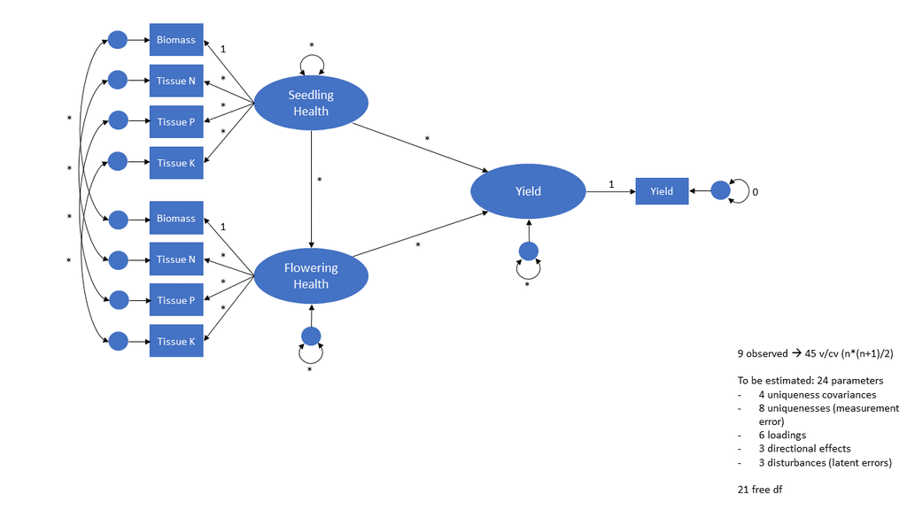

```r
knitr::include_graphics(here('Other', 'SEM Outline', 'Slide2.PNG'))
```

Where tissue nutrients and biomass meaures (boxes) are tied to the observation time (seedling, flowering). Errors on these may or may not be correlated. Stars are unknonw parameters. Boxes are observed (manifest) variables. Ovals are conceptual (latent) variables, which are essentially the covariance of the observed. Circles are residual errors of observed errors - i.e. the variation that doesn’t correlate with the other observed variables.

### Approach

1. Munge data into an appropriate form - a wide dataframe, with measures repeated by time point.
2. Test the measurement model first: Do biomass and nutrients indicate plant health? Are errors correlated? These will be tested using confirmatory factor analysis. Biomass is the ultimate measure of health, and thus will always be fixed at 1.
3. Test the structural model. These are the arrows among health/yield.

### Wrangle to SEM dataframe

Steps: 1. ID common factors across T1 and T2 2. Separate into T1 and T2 data 3. Rename measures to include time point 4. Remove empty columns 5. Merge

```r
# Drop soils data
soils = c('X0_', 'X10_') %>% #tags indicating soil sampling depth
  sapply(function(x) grepl(x, names(plot))) %>%
  rowSums %>%
  is_greater_than(0) #don't want either tag
semdf = plot[,!soils]

# ID factors that indicate sample units across sample timepoints.
drop_facts = c('SAMPLE_ID', 'SAMPLING') # do not indicate sample units
facts = sapply(semdf, is.factor) %>%
  semdf[.] %>%
  names
facts %<>%
  sapply(function(x) !(x %in% drop_facts)) %>%
  facts[.]
is_ID = grepl('_ID', facts)
facts %<>% .[!is_ID]


# Split into T1 and T2
time_split = split(semdf, semdf[, "SAMPLING"])
names(time_split) %<>%
  gsub('flowering', 'T2', .) %>%
  gsub('seedling', 'T1', .)

# Rename data to reflect sample time. Subset factors per above.
time_split %<>%
  names %>%
  lapply(function(y) {
    x = time_split[[y]]

    # select data
    data = sapply(x, is.numeric) %>%
      x[.]
    data %<>%
      sapply(function(x) sum(!is.na(x)) > 0) %>%
      data[.]
    names(data) %<>% paste(y, sep="_")

    # select factors
    factors = x[facts]

    # recombine
    out = cbind(factors, data) %>%
      as.data.frame

    return(out)
  })

# Re-merge the dataframes
semdf = time_split[[1]]
for(i in 2:length(time_split)) {
  semdf = merge(semdf, time_split[[i]], by=facts)
}

# Relable once-measured plant variables as such (without time info)
oncevars = c('STAGE_1', 'STAGE_V7', 'STAGE_R3', 'YIELD', 'STAND_PLOT')
for(i in oncevars) {
  tt = grep(i,
            names(semdf))
  names(semdf)[tt] = i
}

# Year as an indicator (for 2017)
yearmat = model.matrix( ~ YEAR, data=semdf) # could also do YEAR == '2017'
semdf[, 'iYEAR'] = yearmat[, 2]

# Results!
names(semdf)
```

```
##  [1] "CROP"                  "YEAR"                  "PLOT"
##  [4] "TREATMENT"             "ROT"                   "ROTATION"
##  [7] "REP"                   "PREVIOUS_CROP"         "YEARS"
## [10] "TYPE"                  "DW_PLOT_T2"            "AV_DW_T2"
## [13] "STAGE_V7"              "STAGE_R3"              "P_T2"
## [16] "K_T2"                  "S_T2"                  "CA_T2"
## [19] "MG_T2"                 "ZN_T2"                 "MN_T2"
## [22] "B_T2"                  "CU_T2"                 "FE_T2"
## [25] "N_T2"                  "C_T2"                  "C_N_T2"
## [28] "YIELD"                 "TEMPERATURE_T2"        "VMOISTURE_T2"
## [31] "SHOOT_MOISTURE_T2"     "TEMPERATURE_VAR_T2"    "VMOISTURE_VAR_T2"
## [34] "SHOOT_MOISTURE_VAR_T2" "NODULATION_T2"         "STAND_PLOT"
## [37] "STAGE_V2_T1"           "DW_PLOT_T1"            "AV_DW_T1"
## [40] "P_T1"                  "K_T1"                  "S_T1"
## [43] "CA_T1"                 "MG_T1"                 "ZN_T1"
## [46] "MN_T1"                 "B_T1"                  "CU_T1"
## [49] "FE_T1"                 "N_T1"                  "C_T1"
## [52] "C_N_T1"                "TEMPERATURE_T1"        "VMOISTURE_T1"
## [55] "SHOOT_HEIGHT_T1"       "SHOOT_MOISTURE_T1"     "TEMPERATURE_VAR_T1"
## [58] "VMOISTURE_VAR_T1"      "SHOOT_HEIGHT_VAR_T1"   "SHOOT_MOISTURE_VAR_T1"
## [61] "NODULATION_T1"         "iYEAR"
```

### Corn

First, scale the data and transform. Then run a model.

#### Scale and transform

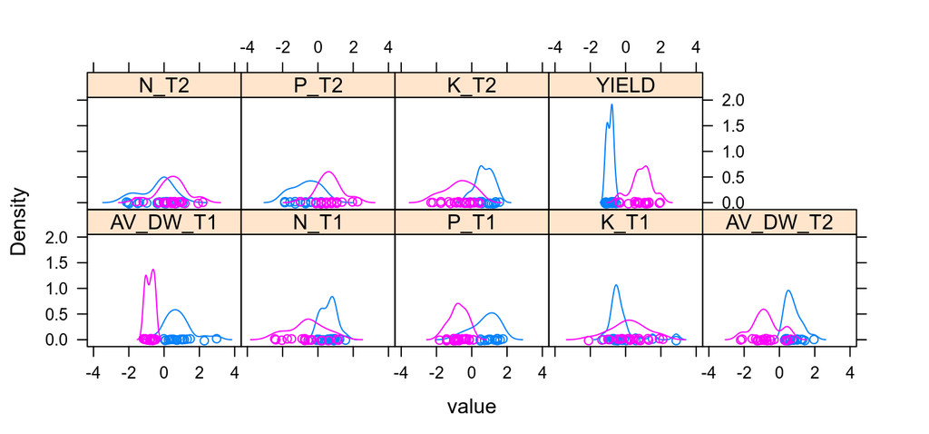

```r
crop = 'corn'
predictors = c('AV_DW', 'N', 'P', 'K')  # both T1 and T2
yield = 'YIELD'
covariates = 'iYEAR'

# expand predictors to T1 and T2
predictor_tags = c('_T1', '_T2') %>%
  sapply(function(x) rep(x, length(predictors))) %>%
  c
predictors %<>% paste0(predictor_tags)

# subset to crop
dd = subset(semdf, CROP==crop, select=c(predictors, yield, covariates)) %>%
  droplevels

# Scale/Center numerics
dd[, c(yield, predictors)] %<>% lapply(scale)

# View distributions of factors
pltdf = dd
pltdf[, 'iYEAR'] %<>% as.factor
pltdf %<>% melt

densityplot( ~ value | variable, group=iYEAR, data=pltdf)
```

**Model Code** These models use year as a predictor for all measured variables. This is preferable to groupwise SEM because we are not interested in differences in paths among years, but rather, overall paths across years (including year for each partials out the year effect, while maintaining correct degrees of freedom, at the expense of busier graphs). Yet we still need to account for (very large) year effects on each variable, otherwise the paths will be dominated by year-induced covariances.

```r
{sem_latent =
  "
  HEALTH_T1 =~ AV_DW_T1 + N_T1 + P_T1 + K_T1
  HEALTH_T2 =~ AV_DW_T2 + N_T2 + P_T2 + K_T2
  PERFORMANCE =~ YIELD
  "
}


{sem_regression = "
  PERFORMANCE ~ HEALTH_T1 + HEALTH_T2
  HEALTH_T2 ~ HEALTH_T1
  "
}

{cfa_covariates = "
  # PERFORMANCE + HEALTH_T2 + HEALTH_T1 ~ iYEAR
  AV_DW_T1 + AV_DW_T2 + N_T1 + N_T2 + P_T1 + P_T2 + K_T1 + K_T2 + YIELD ~ iYEAR
  "
}

{sem_covar =
  "
  # latent variable covariances implied in CFA

  # indicator covariances
  AV_DW_T1 ~~ AV_DW_T2
  # N_T1 ~~ N_T2  # removed due to lack of relationship. Estimated negative in some cases.
  P_T1 ~~ P_T2
  K_T1 ~~ K_T2
  "
}

{sem_var =
  "
  # indicator disturbances
  YIELD ~~ 0*YIELD
  # HEALTH_T1 ~~ 1*HEALTH_T1
  "
}

{sem_intercepts =
  "
  # automatically at zero
  "
}
```

#### Measurement model

Are the latent variables justified - on theoretical grounds? Will use a confirmatory factor analysis model first - relationships between latent variables (health, performance) are covariances rather than regressions.

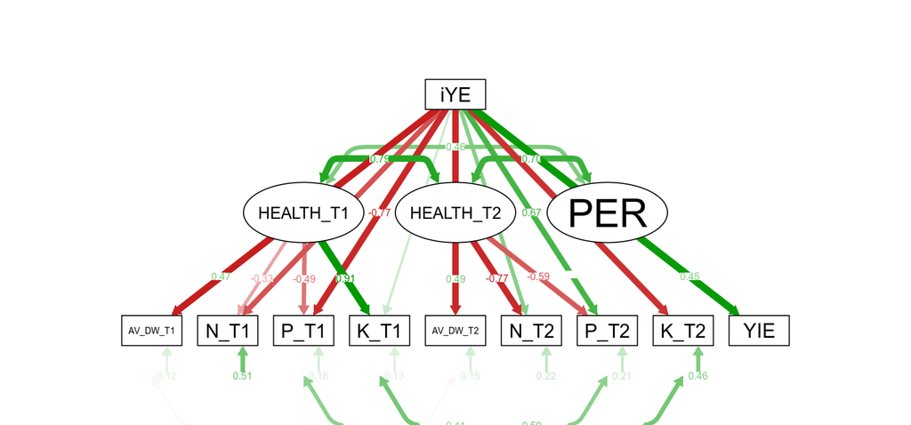

```r
mod1 = paste(sem_latent, sem_covar, cfa_covariates) %>%
  cfa(data=dd)

fitstats = mod1@Fit@test$standard

varsize = 8
semPaths(mod1, what='std',
         rotation=1, style='lisrel', layout='tree',
         curvePivot=TRUE, sizeMan=varsize, sizeMan2=varsize/2, sizeLat=2*varsize, sizeLat2=varsize,
         )
```

```r
# summary(mod1, standardized=TRUE)
```

Model Fit Indices: *χ*<sup>2</sup> = 33.19; *p* = 0.059; 22 df. This is a mediocre model.

Nonetheless, a quick glance at this shows a few interesting outcomes.

1. Signs of coefficients and covariances are constant across years. We don’t see a year effect.
2. Higher nutrient concentrations tend to indicate lower “health” - especially at T2. This suggests that nutrient uptake is not limiting - that rather, plants can grow more biomass per nutrient, diluting nutrient uptake in the biomass. Why might this be?
3. Related to this, nutrient content at T2 is inversely related to yield. Healthier plants have lower nutrient content.
4. Dry weight is a good indicator of health.
5. Potassium at T1 is also a good indicator of health at T1, equivalent to dry weight, but not at T2. Why?
6. Health at T1 covaries with health at T2, but not with yield very well. Health at T2 covaries yield.

We can look at modification indices to see what relationships might be important that we didn’t find.

```r
# calc modification indices
mod_indices = modindices(mod1)

# sort by modification indice (importance)
sort_df = order(mod_indices[, 'mi'], decreasing=TRUE)
mod_indices %<>%
  .[sort_df, ] %>%
  subset(mi>3)
mod_indices
```

|  | lhs | op | rhs | mi | epc | sepc.lv | sepc.all | sepc.nox |
| --- | --- | --- | --- | --- | --- | --- | --- | --- |
| 99 | N_T2 | ~ | P_T2 | 13.337205 | 1.01093502 | 1.01093502 | 1.0084783 | 1.0084783 |
| 136 | YIELD | ~ | AV_DW_T2 | 10.554310 | 0.55753154 | 0.55753154 | 0.5571267 | 0.5571267 |
| 64 | AV_DW_T2 | ~~ | YIELD | 10.236431 | 0.08228336 | 0.08228336 | NA | NA |
| 65 | N_T2 | ~~ | P_T2 | 9.162506 | 0.16379831 | 0.16379831 | 0.7870865 | 0.7870865 |
| 114 | P_T2 | ~ | N_T2 | 9.162500 | 0.76114286 | 0.76114286 | 0.7629970 | 0.7629970 |
| 86 | AV_DW_T2 | ~ | YIELD | 8.360450 | 0.72738542 | 0.72738542 | 0.7279140 | 0.7279140 |
| 142 | YIELD | ~ | K_T2 | 6.219568 | 0.19898702 | 0.19898702 | 0.1989788 | 0.1989788 |
| 141 | YIELD | ~ | K_T1 | 5.659106 | 0.51321180 | 0.51321180 | 0.5174112 | 0.5174112 |
| 123 | K_T1 | ~ | P_T1 | 4.704383 | 0.83897379 | 0.83897379 | 0.8356470 | 0.8356470 |
| 70 | K_T2 | ~~ | YIELD | 4.555497 | 0.07222432 | 0.07222432 | NA | NA |

[output cut: 9 more lines]

The first three columns specify the relationship. We’re especially interested in the “mi” column. Per Brown and Moore (Ch. 22 in Hoyle, 2015), this is the expected decrease in $\chi^2$ if we *didn’t* constrain the noted parameter - which is currently constrained at zero, formally. Values larger than 3.84 are “worth consideration”. However, we are more interested in whether a paramter is both *important* and *theoretically justifiable*.

Generally, it looks like yield, biomass, and maybe potassium are related.

Overall, we might have come to a similar conclusion as from looking at the graph. Let’s run a structural model (i.e. latent covariances are now regressions) to improve the interpretations.

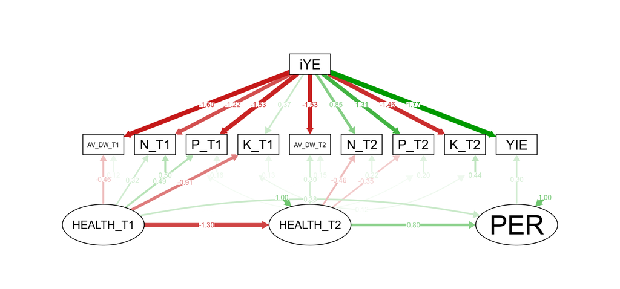

```r
mod_sem_large = paste(sem_latent, sem_regression, sem_var, sem_covar, cfa_covariates) %>%
  sem(data=dd, std.lv=TRUE)

fitstats = mod_sem_large@Fit@test$standard

varsize = 8
semPaths(mod_sem_large, what='est',
         rotation=1, style='lisrel', layout='tree2',
         curvePivot=FALSE, sizeMan=varsize, sizeMan2=varsize/2, sizeLat=2*varsize, sizeLat2=varsize,
         )
```

Model Fit Indices: *χ*<sup>2</sup> = 33.19; *p* = 0.059; 22 df. This is a poor model.

#### Reduced SEM

Moving forward, nutrients are not indicative of plant health in this case, excluding potassium in T1. Biomass is indicative. We will test two models:

1. Seedling health as indicated equally by biomass and potassium. Yield the result flowering health.
2. Seedling health as biomass only. Yield the result of flowering health.

Potassium is dropped because even in the reduced model, it ruins fit. Removing it allows a reasonable model. AICs cannot be compared, however.

```r
with_potassium = {
  "
  HEALTH_T1 =~ a*AV_DW_T1 + a*K_T1  # constrained to equality for identification purposes.
  HEALTH_T2 =~ AV_DW_T2
  PERFORMANCE =~ YIELD

  PERFORMANCE ~ HEALTH_T2# + HEALTH_T1
  HEALTH_T2 ~ HEALTH_T1

  AV_DW_T1 + AV_DW_T2 + YIELD ~ iYEAR
  K_T1 ~ iYEAR
  "
} %>%
  sem(data=dd, std.lv=FALSE, se='boot')

without_potassium_mediation = {
  "
  HEALTH_T1 =~ AV_DW_T1# + K_T1
  HEALTH_T2 =~ AV_DW_T2
  PERFORMANCE =~ YIELD

  PERFORMANCE ~ HEALTH_T2 + HEALTH_T1
  HEALTH_T2 ~ HEALTH_T1

  AV_DW_T1 + AV_DW_T2 + YIELD ~ iYEAR

  #PERFORMANCE ~~ 0*K_T1

  "
} %>%
  sem(data=dd, std.lv=FALSE, se='boot')

without_potassium_direct = {
  "
  HEALTH_T1 =~ AV_DW_T1# + K_T1
  HEALTH_T2 =~ AV_DW_T2
  PERFORMANCE =~ YIELD

  PERFORMANCE ~ HEALTH_T2# + HEALTH_T1
  HEALTH_T2 ~ HEALTH_T1

  AV_DW_T1 + AV_DW_T2 + YIELD ~ iYEAR

  #PERFORMANCE ~~ 0*K_T1

  "
} %>%
  sem(data=dd, std.lv=FALSE, se='boot')

model_compares = anova(with_potassium, without_potassium_mediation, without_potassium_direct) %T>%
  print
```

```
## Chi-Squared Difference Test
##
##                             Df    AIC    BIC   Chisq Chisq diff Df diff
## without_potassium_mediation  0 173.79 188.99  0.0000
## without_potassium_direct     1 172.48 185.99  0.6907     0.6907       1
## with_potassium               3 259.35 277.92 17.4927    16.8021       2
##                             Pr(>Chisq)
## without_potassium_mediation
## without_potassium_direct     0.4059401
## with_potassium               0.0002246 ***
## ---
## Signif. codes:  0 '***' 0.001 '**' 0.01 '*' 0.05 '.' 0.1 ' ' 1
```

The best model is without_potassium_direct. It has the lowest AIC, and is unsaturated and well-fitting to boot. The with_potassium model is surprisingly less parsimonious than the full CFA.

```r
corn_health_model = which.min(model_compares$AIC) %>%
  rownames(model_compares)[.] %>%
  get

lavaanPlot(model=corn_health_model, coef=TRUE, stand=FALSE)
```

[interactive chart not shown]

```r
summary(corn_health_model, std=TRUE)
```

```
## lavaan 0.6-5 ended normally after 29 iterations
##
##   Estimator                                         ML
##   Optimization method                           NLMINB
##   Number of free parameters                          8
##
##   Number of observations                            40
##
## Model Test User Model:
##
##   Test statistic                                 0.691
##   Degrees of freedom                                 1
##   P-value (Chi-square)                           0.406
##
## Parameter Estimates:
##
##   Standard errors                            Bootstrap
##   Number of requested bootstrap draws             1000
##   Number of successful bootstrap draws            1000
##
## Latent Variables:
##                    Estimate  Std.Err  z-value  P(>|z|)   Std.lv  Std.all
##   HEALTH_T1 =~
##     AV_DW_T1          1.000                               0.576    0.583
##   HEALTH_T2 =~
##     AV_DW_T2          1.000                               0.623    0.631
##   PERFORMANCE =~
##     YIELD             1.000                               0.440    0.446
##
## Regressions:
##                    Estimate  Std.Err  z-value  P(>|z|)   Std.lv  Std.all
##   PERFORMANCE ~
##     HEALTH_T2         0.503    0.114    4.413    0.000    0.712    0.712
##   HEALTH_T2 ~
##     HEALTH_T1         0.465    0.167    2.781    0.005    0.430    0.430
##   AV_DW_T1 ~
##     iYEAR            -1.604    0.186   -8.644    0.000   -1.604   -0.812
##   AV_DW_T2 ~
##     iYEAR            -1.532    0.207   -7.406    0.000   -1.532   -0.776
##   YIELD ~
##     iYEAR             1.768    0.146   12.076    0.000    1.768    0.895
##
## Variances:
##                    Estimate  Std.Err  z-value  P(>|z|)   Std.lv  Std.all
##    .AV_DW_T1          0.000                               0.000    0.000
##    .AV_DW_T2          0.000                               0.000    0.000
##    .YIELD             0.000                               0.000    0.000
##     HEALTH_T1         0.332    0.125    2.664    0.008    1.000    1.000
##    .HEALTH_T2         0.316    0.072    4.374    0.000    0.815    0.815
##    .PERFORMANCE       0.096    0.026    3.685    0.000    0.493    0.493
```

### Soybean

First, scale the data and transform. Then run a model.

#### Scale and transform

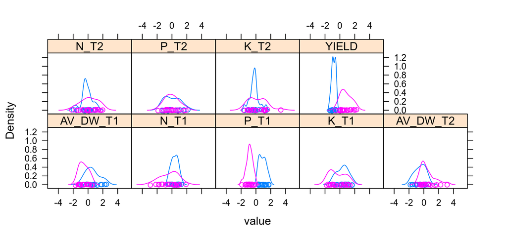

```r
crop = 'soy'
predictors = c('AV_DW', 'N', 'P', 'K')
yield = 'YIELD'
covariates = 'iYEAR'

# expand predictors to T1 and T2
predictor_tags = c('_T1', '_T2') %>%
  sapply(function(x) rep(x, length(predictors))) %>%
  c
predictors %<>% paste0(predictor_tags)

# subset to crop
dd = subset(semdf, CROP==crop, select=c(predictors, yield, covariates)) %>%
  droplevels

# Scale/Center numerics
dd[, c(yield, predictors)] %<>% lapply(scale)

# View distributions of factors
pltdf = dd
pltdf[, 'iYEAR'] %<>% as.factor
pltdf %<>% melt

densityplot( ~ value | variable, group=iYEAR, data=pltdf)
```

These generally look great.

**Model Code –>**

```r
{sem_latent =
  "
  HEALTH_T1 =~ AV_DW_T1 + N_T1 + P_T1 + K_T1
  HEALTH_T2 =~ AV_DW_T2 + N_T2 + P_T2 + K_T2
  PERFORMANCE =~ YIELD
  "
}

{cfa_covariates = "
  # PERFORMANCE + HEALTH_T2 + HEALTH_T1 ~ iYEAR
  AV_DW_T1 + AV_DW_T2 + N_T1 + N_T2 + P_T1 + P_T2 + K_T1 + K_T2 + YIELD ~ iYEAR
  "
}

{sem_regression = "
  PERFORMANCE ~ HEALTH_T1 + HEALTH_T2
  HEALTH_T2 ~ HEALTH_T1

  "
}

{sem_covar =
  "
  # latent variable covariances implied in CFA

  # indicator covariances
  AV_DW_T1 ~~ AV_DW_T2
  # N_T1 ~~ N_T2
  P_T1 ~~ P_T2
  K_T1 ~~ K_T2
  "
}

{sem_var =
  "
  # indicator disturbances
  # YIELD ~~ 0*YIELD
  "
}

{sem_intercepts =
  "
  # automatically at zero
  "
}
```

#### Measurement model

Are the latent variables justified - on theoretical grounds? Will use a confirmatory factor analysis model first - relationships between latent variables (health, performance) are covariances rather than regressions.

```r
mod1 = paste(sem_latent, sem_var, sem_covar, cfa_covariates) %>%
  cfa(data=dd,
      std.lv=TRUE)

fitstats = mod1@Fit@test$standard
anova(mod1)
```

|  | Df | AIC | BIC | Chisq | Chisq diff | Df diff | Pr(>Chisq) |
| --- | --- | --- | --- | --- | --- | --- | --- |
| Saturated | 0 | NA | NA | 0.00000 | NA | NA | NA |
| Model | 22 | 756.0086 | 809.2426 | 45.30521 | 45.30521 | 22 | 0.002427014 |

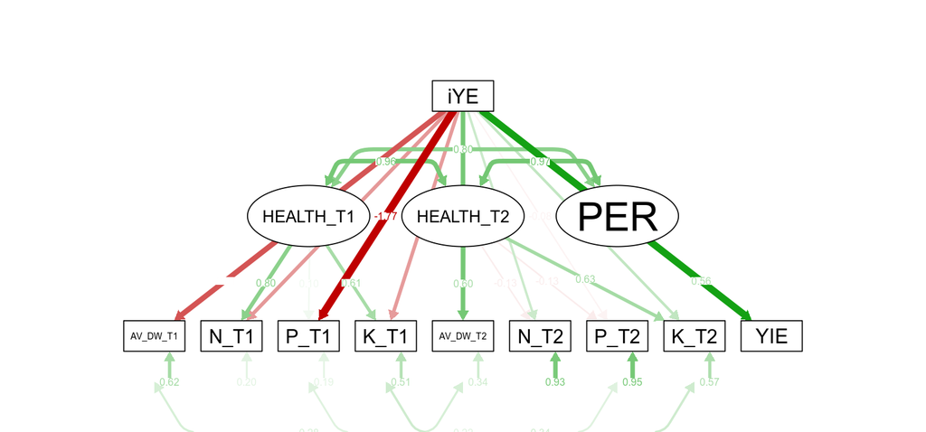

```r
varsize = 8
semPaths(mod1, what='est',
         rotation=1, style='lisrel', layout='tree',
         curvePivot=TRUE, sizeMan=varsize, sizeMan2=varsize/2, sizeLat=2*varsize, sizeLat2=varsize,
         )
```

```r
# summary(mod1, standardized=TRUE)
```

Deviance is huge. This is a terrible model that doesn’t reflect the data.

What it does say is that nutrients are not consistently related to health, if we view health as primarily defined by biomass.

We can try reducing it to biomasses and yield, per the corn model:

#### Reduced SEM

Moving forward, nutrients are not indicative of plant health in this case, except possibly potassium at T2. We’ll run a similar series of models as with corn.

```r
with_potassium = {
  "
  HEALTH_T1 =~ AV_DW_T1
  HEALTH_T2 =~ a*AV_DW_T2 + a*K_T2 # constrained to equality for identification purposes.
  PERFORMANCE =~ YIELD

  PERFORMANCE ~ HEALTH_T2
  HEALTH_T2 ~ HEALTH_T1

  AV_DW_T1 + AV_DW_T2 + YIELD ~ iYEAR
  K_T1 ~ iYEAR
  "
} %>%
  sem(data=dd, std.lv=FALSE, se='boot')

without_potassium = {
  "
  HEALTH_T1 =~ AV_DW_T1
  HEALTH_T2 =~ AV_DW_T2
  PERFORMANCE =~ YIELD

  PERFORMANCE ~ HEALTH_T2
  HEALTH_T2 ~ HEALTH_T1

  AV_DW_T1 + AV_DW_T2 + YIELD ~ iYEAR
  "
} %>%
  sem(data=dd, std.lv=FALSE, se='boot')

model_compares = anova(with_potassium, without_potassium) %T>%
  print
```

```
## Chi-Squared Difference Test
##
##                   Df    AIC    BIC   Chisq Chisq diff Df diff Pr(>Chisq)
## without_potassium  1 231.52 244.83  4.0281
## with_potassium     7 442.61 464.23 50.1293     46.101       6  2.826e-08 ***
## ---
## Signif. codes:  0 '***' 0.001 '**' 0.01 '*' 0.05 '.' 0.1 ' ' 1
```

```r
soy_health_model = which.min(model_compares$AIC) %>%
  rownames(model_compares)[.] %>%
  get

lavaanPlot(model=soy_health_model, coef=TRUE, stand=FALSE)
```

[interactive chart not shown]

```r
summary(soy_health_model, std=TRUE)
```

```
## lavaan 0.6-5 ended normally after 27 iterations
##
##   Estimator                                         ML
##   Optimization method                           NLMINB
##   Number of free parameters                          8
##
##   Number of observations                            39
##
## Model Test User Model:
##
##   Test statistic                                 4.028
##   Degrees of freedom                                 1
##   P-value (Chi-square)                           0.045
##
## Parameter Estimates:
##
##   Standard errors                            Bootstrap
##   Number of requested bootstrap draws             1000
##   Number of successful bootstrap draws            1000
##
## Latent Variables:
##                    Estimate  Std.Err  z-value  P(>|z|)   Std.lv  Std.all
##   HEALTH_T1 =~
##     AV_DW_T1          1.000                               0.790    0.800
##   HEALTH_T2 =~
##     AV_DW_T2          1.000                               0.864    0.875
##   PERFORMANCE =~
##     YIELD             1.000                               0.561    0.569
##
## Regressions:
##                    Estimate  Std.Err  z-value  P(>|z|)   Std.lv  Std.all
##   PERFORMANCE ~
##     HEALTH_T2         0.482    0.086    5.601    0.000    0.741    0.741
##   HEALTH_T2 ~
##     HEALTH_T1         0.532    0.139    3.832    0.000    0.487    0.487
##   AV_DW_T1 ~
##     iYEAR            -1.185    0.257   -4.618    0.000   -1.185   -0.600
##   AV_DW_T2 ~
##     iYEAR             0.955    0.275    3.469    0.001    0.955    0.484
##   YIELD ~
##     iYEAR             1.625    0.181    8.963    0.000    1.625    0.823
##
## Variances:
##                    Estimate  Std.Err  z-value  P(>|z|)   Std.lv  Std.all
##    .AV_DW_T1          0.000                               0.000    0.000
##    .AV_DW_T2          0.000                               0.000    0.000
##    .YIELD             0.000                               0.000    0.000
##     HEALTH_T1         0.624    0.123    5.069    0.000    1.000    1.000
##    .HEALTH_T2         0.570    0.160    3.563    0.000    0.763    0.763
##    .PERFORMANCE       0.142    0.038    3.697    0.000    0.450    0.450
```

# Rotation aspects affecting plant health

With plant health at the within-season sampling points established as generally predictive of yield, we are interested in which aspects of rotation might predict plant health.

Our hypotheses are:

1. **Hypothesis** Alternative previous crops will increase seedling health, due to transient/dynamic crop effects on the soil.
2. **Hypothesis** Long rotations will improve flowering health, due to deeper, more static rotation legacies.

## Corn

### Seedling

As with yield, we first test for an overall rotation effect, then delve into the aspects of rotation if the overall effect is supported.

```r
crop = 'corn'
response = 'AV_DW'
timing = 'seedling'

df = subset(plot, CROP==crop & SAMPLING==timing, select=c('YEAR', 'REP', 'ROTATION', response))
df[, response] %<>% scale

mod = paste(response, 'ROTATION + YEAR/REP', sep='~') %>%
  formula %>%
  lm(data=df) %>%
  step(trace=1) %>%
  extract2('call')
```

```
## Start:  AIC=-38.16
## AV_DW ~ ROTATION + YEAR/REP
##
##            Df Sum of Sq     RSS     AIC
## - YEAR:REP  6    0.3175  8.7740 -48.684
## <none>                   8.4564 -38.158
## - ROTATION  4    4.5032 12.9597 -29.081
##
## Step:  AIC=-48.68
## AV_DW ~ ROTATION + YEAR
##
##            Df Sum of Sq    RSS     AIC
## <none>                   8.774 -48.684
## - ROTATION  4    4.5032 13.277 -40.113
## - YEAR      1   25.7228 34.497   4.079
```

```r
a = eval(mod) %>%
  Anova

mod_name = paste(crop, 'None', timing, response, sep='_')
anova_out[[mod_name]] = a

signif(a, 3)
```

|  | Sum Sq | Df | F value | Pr(>F) |
| --- | --- | --- | --- | --- |
| ROTATION | 4.50 | 4 | 4.36 | 5.91e-03 |
| YEAR | 25.70 | 1 | 99.70 | 1.22e-11 |
| Residuals | 8.77 | 34 | NA | NA |

corn seedling biomass varied among rotation (*p* = 0.0059). What aspects of rotation seem to predict this?

```r
df = subset(plot, CROP==crop & SAMPLING==timing, select=c('YEAR', 'REP', 'ROTATION', response))
mod = paste(response, 'YEAR', sep='~') %>%
  formula %>%
  lm(data=df) %>%
  residuals %>%
  data.frame(df, residuals=.) %>% # add results (residuals) to the dataframe
  lm(residuals ~ ROTATION, data=.) %>%   # run the main model
  glht(linfct=contrasts[[crop]])  # contrasts
mod_s = summary(mod) %T>%
  print %>%
  extract2('test')
```

```
##
##   Simultaneous Tests for General Linear Hypotheses
##
## Fit: lm(formula = residuals ~ ROTATION, data = .)
##
## Linear Hypotheses:
##                       Estimate Std. Error t value Pr(>|t|)
## ROTATION_LENGTH == 0  -0.05769    0.02034  -2.836   0.0202 *
## FOLLOW_SOY == 0       -0.05150    0.02245  -2.295   0.0728 .
## FOLLOW_SUNFLOWER == 0  0.03431    0.02191   1.566   0.2947
## ---
## Signif. codes:  0 '***' 0.001 '**' 0.01 '*' 0.05 '.' 0.1 ' ' 1
## (Adjusted p values reported -- single-step method)
```

corn seedling biomass was 0.058 +/- 0.02 g/plant lower in the two-year rotation than in 4-year rotations (*p* = 0.02). corn seedling biomass was marginally lower following soybean (*p* = 0.073), and unaffected by sunflower (*p* = 0.29).

```r
cr = gather_glht(mod, crop, timing)
contrast_results %<>%
  rbind(cr) %>%
  as.data.frame
```

### Flowering

```r
crop = 'corn'
response = 'AV_DW'
timing = 'flowering'

df = subset(plot, CROP==crop & SAMPLING==timing, select=c('YEAR', 'REP', 'ROTATION', 'PLOT', 'CROP', response))
t1_df = subset(plot, CROP==crop & SAMPLING=='seedling', select=c('YEAR', 'CROP', 'PLOT', 'AV_DW'))
colnames(t1_df)[4] = 'T1_AV_DW'

df = merge(df, t1_df, by=c('CROP', 'YEAR', 'PLOT'))

mod = paste(response, 'ROTATION + T1_AV_DW + YEAR/REP', sep='~') %>%
  formula %>%
  lm(data=df) %>%
  step(trace=1) %>%
  extract2('call')
```

```
## Start:  AIC=220.12
## AV_DW ~ ROTATION + T1_AV_DW + YEAR/REP
##
##            Df Sum of Sq    RSS    AIC
## - YEAR:REP  6    744.93 5870.1 213.55
## <none>                  5125.1 220.12
## - ROTATION  4   1427.66 6552.8 221.95
## - T1_AV_DW  1    636.33 5761.5 222.80
##
## Step:  AIC=213.55
## AV_DW ~ ROTATION + T1_AV_DW + YEAR
##
##            Df Sum of Sq    RSS    AIC
## <none>                  5870.1 213.55
## - T1_AV_DW  1    479.26 6349.3 214.69
## - ROTATION  4   1513.20 7383.3 214.72
## - YEAR      1   1610.40 7480.5 221.25
```

```r
a = eval(mod) %>%
  Anova

mod_name = paste(crop, 'None', timing, response, sep='_')
anova_out[[mod_name]] = a

signif(a, 3)
```

|  | Sum Sq | Df | F value | Pr(>F) |
| --- | --- | --- | --- | --- |
| ROTATION | 1510 | 4 | 2.13 | 0.09960 |
| T1_AV_DW | 479 | 1 | 2.69 | 0.11000 |
| YEAR | 1610 | 1 | 9.05 | 0.00499 |
| Residuals | 5870 | 33 | NA | NA |

Essentially, biomass at seedling is interchangeable with rotation, but rotation is slightly more predictive. We will run that model:

```r
mod = paste(response, 'ROTATION + YEAR', sep='~') %>%
  formula %>%
  lm(data=df)
a = Anova(mod)

mod_name = paste(crop, 'None', timing, response, sep='_')
anova_out[[mod_name]] = a

signif(a, 3)
```

|  | Sum Sq | Df | F value | Pr(>F) |
| --- | --- | --- | --- | --- |
| ROTATION | 2710 | 4 | 3.63 | 1.44e-02 |
| YEAR | 13700 | 1 | 73.40 | 5.25e-10 |
| Residuals | 6350 | 34 | NA | NA |

corn flowering biomass also varied among rotations (*p* = 0.014). What aspects of rotation seem to predict this?

**Note**: mediation analysis by SEM not possible due to low sample sizes and lots of parameters for a composite variable. We use regression as an alternative.

```r
# df = subset(plot, CROP==crop & SAMPLING==timing, select=c('YEAR', 'REP', 'ROTATION', response))
mod = paste(response, 'YEAR + AV_DW', sep='~') %>%
  formula %>%
  lm(data=df) %>%
  residuals %>%
  data.frame(df, residuals=.) %>% # add results (residuals) to the dataframe
  lm(residuals ~ ROTATION, data=.) %>%   # run the main model
  glht(linfct=contrasts[[crop]])  # contrasts
mod_s = summary(mod) %T>%
  print %>%
  extract2('test')
```

[output not shown]

corn flowering biomass responded only to rotation length: It was lower by 18 +/- 5.7 g/plant in the two-year rotation than in 4-year rotations (*p* = 0.0074). Neither previous crop affected corn flowering biomass (following soybean: *p* = 1; following sunflower: *p* = 0.52).

```r
cr = gather_glht(mod, crop, timing)
contrast_results %<>%
  rbind(cr) %>%
  as.data.frame
```

## Soy

### Seedling

As with yield, we first test for an overall rotation effect, then delve into the aspects of rotation if the overall effect is supported.

```r
crop = 'soy'
response = 'AV_DW'
timing = 'seedling'

df = subset(plot, CROP==crop & SAMPLING==timing, select=c('YEAR', 'REP', 'ROTATION', response))
# df[, response] %<>% scale

mod = paste(response, 'ROTATION + YEAR/REP', sep='~') %>%
  formula %>%
  lm(data=df) %>%
  step(trace=1) %>%
  extract2('call')
```

```
## Start:  AIC=-203.07
## AV_DW ~ ROTATION + YEAR/REP
##
##            Df Sum of Sq     RSS     AIC
## - YEAR:REP  6  0.011430 0.12691 -211.38
## <none>                  0.11548 -203.06
## - ROTATION  4  0.092196 0.20768 -188.18
##
## Step:  AIC=-211.38
## AV_DW ~ ROTATION + YEAR
##
##            Df Sum of Sq     RSS     AIC
## <none>                  0.12691 -211.38
## - ROTATION  4  0.092162 0.21907 -198.09
## - YEAR      1  0.125153 0.25207 -186.62
```

```r
a = eval(mod) %>%
  Anova

mod_name = paste(crop, 'None', timing, response, sep='_')
anova_out[[mod_name]] = a

signif(a, 3)
```

|  | Sum Sq | Df | F value | Pr(>F) |
| --- | --- | --- | --- | --- |
| ROTATION | 0.0922 | 4 | 5.99 | 9.73e-04 |
| YEAR | 0.1250 | 1 | 32.50 | 2.30e-06 |
| Residuals | 0.1270 | 33 | NA | NA |

soy seedling biomass varied among rotation (*p* = 9.710^{-4}). What aspects of rotation seem to predict this?

```r
df = subset(plot, CROP==crop & SAMPLING==timing, select=c('YEAR', 'REP', 'ROTATION', response))
mod = paste(response, 'YEAR', sep='~') %>%
  formula %>%
  lm(data=df) %>%
  residuals %>%
  data.frame(df, residuals=.) %>% # add results (residuals) to the dataframe
  lm(residuals ~ 0 + ROTATION, data=.) %>%   # run the main model
  glht(linfct=contrasts[[crop]])  # contrasts
mod_s = summary(mod) %T>%
  print %>%
  extract2('test')
```

```
##
##   Simultaneous Tests for General Linear Hypotheses
##
## Fit: lm(formula = residuals ~ 0 + ROTATION, data = .)
##
## Linear Hypotheses:
##                      Estimate Std. Error t value Pr(>|t|)
## ROTATION_LENGTH == 0 -0.02311    0.02424  -0.953  0.71495
## FOLLOW_CORN == 0     -0.07768    0.02198  -3.533  0.00355 **
## WITH_PEA == 0         0.06795    0.02198   3.091  0.01177 *
## ---
## Signif. codes:  0 '***' 0.001 '**' 0.01 '*' 0.05 '.' 0.1 ' ' 1
## (Adjusted p values reported -- single-step method)
```

```r
cr = gather_glht(mod, crop, timing)
contrast_results %<>%
  rbind(cr) %>%
  as.data.frame
```

### Flowering

```r
timing = 'flowering'

df = subset(plot, CROP==crop & SAMPLING==timing, select=c('YEAR', 'REP', 'ROTATION', 'PLOT', 'CROP', response))
t1_df = subset(plot, CROP==crop & SAMPLING=='seedling', select=c('YEAR', 'CROP', 'PLOT', 'AV_DW'))
colnames(t1_df)[4] = 'T1_AV_DW'

df = merge(df, t1_df, by=c('CROP', 'YEAR', 'PLOT'))


mod = paste(response, 'ROTATION + T1_AV_DW + YEAR/REP', sep='~') %>%
  formula %>%
  lm(data=df) %>%
  step(trace=0) %>%
  extract2('call')
a = eval(mod) %>%
  Anova

mod_name = paste(crop, 'None', timing, response, sep='_')
anova_out[[mod_name]] = a


signif(a, 3)
```

|  | Sum Sq | Df | F value | Pr(>F) |
| --- | --- | --- | --- | --- |
| ROTATION | 44.1 | 4 | 16.2 | 1.97e-07 |
| YEAR | 18.1 | 1 | 26.5 | 1.18e-05 |
| Residuals | 22.5 | 33 | NA | NA |

soy flowering biomass also varied among rotations (*p* = 210^{-7}). What aspects of rotation seem to predict this?

```r
mod = paste(response, 'YEAR', sep='~') %>%
  formula %>%
  lm(data=df) %>%
  residuals %>%
  data.frame(df, residuals=.) %>% # add results (residuals) to the dataframe
  lm(residuals ~ 0 + ROTATION:T1_AV_DW, data=.) %>%   # run the main model
  glht(linfct=contrasts[[crop]])  # contrasts
mod_s = summary(mod) %T>%
  print %>%
  extract2('test')
```

```
##
##   Simultaneous Tests for General Linear Hypotheses
##
## Fit: lm(formula = residuals ~ 0 + ROTATION:T1_AV_DW, data = .)
##
## Linear Hypotheses:
##                      Estimate Std. Error t value Pr(>|t|)
## ROTATION_LENGTH == 0  -3.0179     0.8167  -3.695  0.00231 **
## FOLLOW_CORN == 0      -4.4839     0.7213  -6.217  < 1e-04 ***
## WITH_PEA == 0          0.5590     0.7213   0.775  0.82185
## ---
## Signif. codes:  0 '***' 0.001 '**' 0.01 '*' 0.05 '.' 0.1 ' ' 1
## (Adjusted p values reported -- single-step method)
```

soy flowering biomass was lower by 3 +/- 0.82 g/plant in the two-year rotation than in 4-year rotations (*p* = 0.0023). It was also lower by 4.5 +/- 0.72 g/plant in rotations following corn (*p* = 1.210^{-6}). Rotations with pea did not affect soy flowering biomass (*p* = 0.82).

```r
cr = gather_glht(mod, crop, timing)
contrast_results %<>%
  rbind(cr) %>%
  as.data.frame
```

Structural equation modeling results highlight how these early- and mid-season rotation effects on plant health ultimately translated to lower yields.

#### Save Objects

Contrasts, pretty names, contrast results

```r
here('Data', 'Contrasts.Rdata') %>%
  save(contrasts, file=.)

here('Data', 'Pretty Names.Rdata') %>%
  save(pretty_crop, pretty_rotation, pretty_time,
       file=.)

here('Results', 'Contrast Results CROP.csv') %>%
  write.csv(contrast_results, ., row.names=FALSE)

here('Data', 'Crop ANOVAs.Rdata') %>%
  save(anova_out,
            file=.)
```